# Introdução à Regressão Linear

De fato, podemos ver como fica a linha de regressão para esse caso:

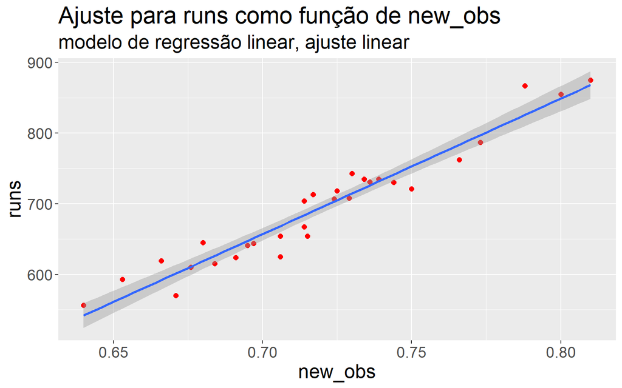

```r
ggplot(data = mlb11, aes(x = new_obs, y = runs)) +
  geom_point(col = "red", size = 2) +
  stat_smooth(method = "lm", formula = y ~ x, se = T) +
  labs(
    title = "Ajuste para runs como função de new_obs",
    subtitle = "modelo de regressão linear, ajuste linear"
  ) +
  theme(text = element_text(size = 18))
```

5. Faça uma análise de diagnóstico do modelo de regressão a partir da variável que você escolheu como melhor preditora dos pontos (variável `runs`).

Para subsidiar a nossa análise, vamos aplicar a função `plot()` ao nosso modelo ajustado, `m10`, a fim de obter a avaliação dos resíduos do modelo.

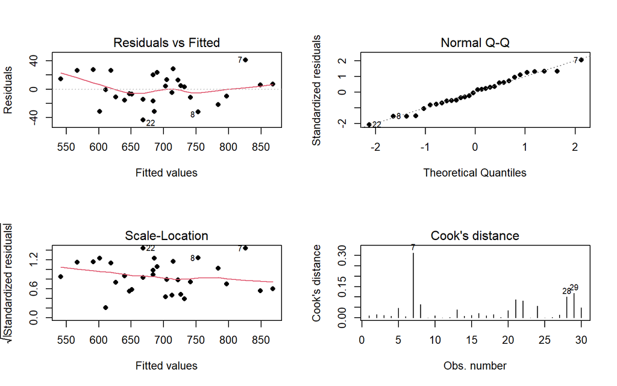

```r
par(mfrow = c(2, 2))
plot(m10, which = c(1:4), pch = 16)
```

**Linearidade**

**Resíduos aproximadamente normais**

Conforme podemos ver no qq-plot mostrado acima, os resíduos amostrais se ajustam razoavelmente bem a uma distribuição normal.

**Variância constante**

Com base no resultado do terceiro quadro mostrado acima, vemos que a hipótese de homocedasticidade é aproximadamente válida, sendo que a variância parece diminuir levemente com o aumento dos valores ajustados.